# project

10

```r
stepwise_model_with_interactions1 <- step(log_model2, direction = "both")
```

```
## Start:  AIC=-299220.9
## log(price) ~ state + year + month + house_size_filled_capped +
##     bed_filled_capped + bath_filled_capped + acre_lot_filled_capped +
##     `bed/house_size_filled_capped` + `bath/house_size_filled_capped` +
##     bed_vs_bath + `bed/acre_lot_filled_capped` + `bath/acre_lot_filled_capped` +
##     `house_size/acre_lot_filled_capped`
##
##                                       Df Sum of Sq    RSS     AIC
## <none>                                              84208 -299221
## - `bed/acre_lot_filled_capped`         1         6  84213 -299205
## - house_size_filled_capped             1         7  84215 -299200
## - `bed/house_size_filled_capped`       1        10  84218 -299191
## - bed_vs_bath                          2        24  84232 -299149
## - bed_filled_capped                    1        37  84245 -299106
## - month                               11        44  84252 -299104
## - `house_size/acre_lot_filled_capped`  1       105  84312 -298897
## - year                                 1       192  84400 -298624
## - `bath/acre_lot_filled_capped`        1       196  84404 -298611
## - `bath/house_size_filled_capped`      1       306  84514 -298268
## - acre_lot_filled_capped               1      1123  85330 -295741
## - bath_filled_capped                   1      5048  89256 -283918
## - state                                8     34479 118686 -209014
```

```r
summary(stepwise_model_with_interactions1)
```

```
##
## Call:
## lm(formula = log(price) ~ state + year + month + house_size_filled_capped +
##     bed_filled_capped + bath_filled_capped + acre_lot_filled_capped +
##     `bed/house_size_filled_capped` + `bath/house_size_filled_capped` +
##     bed_vs_bath + `bed/acre_lot_filled_capped` + `bath/acre_lot_filled_capped` +
##     `house_size/acre_lot_filled_capped`, data = training_data_selected2)
##
## Residuals:
##     Min      1Q  Median      3Q     Max
## -3.5996 -0.3155  0.0231  0.3262  6.8934
##
## Coefficients:
##                                       Estimate Std. Error t value Pr(>|t|)
## (Intercept)                          5.662e+00  2.521e-01  22.456  < 2e-16 ***
## stateMaine                           6.813e-03  1.063e-02   0.641   0.5218
## stateMassachusetts                   6.850e-01  4.279e-03 160.096  < 2e-16 ***
## stateNew Hampshire                   2.273e-01  7.204e-03  31.556  < 2e-16 ***
## stateNew Jersey                      3.419e-01  3.715e-03  92.052  < 2e-16 ***
## stateNew York                        1.112e+00  4.130e-03 269.157  < 2e-16 ***
## statePennsylvania                    8.797e-02  7.881e-03  11.163  < 2e-16 ***
## stateRhode Island                    2.979e-01  6.851e-03  43.484  < 2e-16 ***
## stateVermont                        -1.282e-01  7.841e-03 -16.349  < 2e-16 ***
## year                                 3.067e-03  1.253e-04  24.478  < 2e-16 ***
## month2                              -2.470e-02  5.974e-03  -4.135 3.55e-05 ***
## month3                              -1.121e-03  5.736e-03  -0.195   0.8450
## month4                               5.903e-03  5.712e-03   1.033   0.3014
## month5                               2.377e-02  5.607e-03   4.239 2.24e-05 ***
## month6                               9.551e-03  5.421e-03   1.762   0.0781 .
## month7                               2.640e-02  5.385e-03   4.901 9.52e-07 ***
## month8                               3.535e-04  5.394e-03   0.066   0.9477
## month9                               3.924e-03  5.539e-03   0.708   0.4787
## month10                             -9.025e-03  5.496e-03  -1.642   0.1005
## month11                              1.452e-02  5.666e-03   2.563   0.0104 *
## month12                             -3.477e-03  5.551e-03  -0.626   0.5311
## house_size_filled_capped             1.478e-05  3.122e-06   4.735 2.20e-06 ***
## bed_filled_capped                   -2.502e-02  2.316e-03 -10.805  < 2e-16 ***
## bath_filled_capped                   4.439e-01  3.536e-03 125.528  < 2e-16 ***
## acre_lot_filled_capped               1.760e-02  2.973e-04  59.198  < 2e-16 ***
## `bed/house_size_filled_capped`       1.716e+01  3.042e+00   5.641 1.69e-08 ***
## `bath/house_size_filled_capped`     -1.903e+02  6.153e+00 -30.930  < 2e-16 ***
## bed_vs_bathbed_less_than_bath        2.460e-02  5.104e-03   4.820 1.43e-06 ***
## bed_vs_bathbed_more_than_bath       -2.912e-02  3.800e-03  -7.663 1.82e-14 ***
## `bed/acre_lot_filled_capped`         3.958e-04  9.300e-05   4.256 2.08e-05 ***
## `bath/acre_lot_filled_capped`       -3.281e-03  1.326e-04 -24.745  < 2e-16 ***
## `house_size/acre_lot_filled_capped`  2.862e-06  1.584e-07  18.066  < 2e-16 ***
## ---
## Signif. codes:  0 '***' 0.001 '**' 0.01 '*' 0.05 '.' 0.1 ' ' 1
##
## Residual standard error: 0.566 on 262857 degrees of freedom
## Multiple R-squared:  0.5438, Adjusted R-squared:  0.5437
## F-statistic: 1.011e+04 on 31 and 262857 DF,  p-value: < 2.2e-16
```

11 Stepwise regression for variable selection

```r
# Base model with main effects only
#log_model1 <- lm(log(price) ~., data = training_data_selected1)

# Define a full model with all main effects and all possible two-way interactions
#log_model9 <- lm(log(price) ~ (.)^2, data = training_data_selected1)

# Perform stepwise model selection starting from the base model and going towards the full model
#stepwise_model <- step(log_model1, scope = list(lower = log_model1, upper = log_model9), direction = "both", k=log(n),trace = FALSE)

# Display the summary of the stepwise model
#summary(stepwise_model)
```

lm(formula = log(price) ~ year + state + house_size_filled_capped + bed_filled_capped + bath_filled_capped + acre_lot_filled_capped + state:acre_lot_filled_capped + bath_filled_capped:acre_lot_filled_capped + state:bed_filled_capped + state:house_size_filled_capped + state:bath_filled_capped + year:bed_filled_capped + bed_filled_capped:bath_filled_capped + year:state + year:bath_filled_capped + year:house_size_filled_capped + house_size_filled_capped:bath_filled_capped + bed_filled_capped:acre_lot_filled_capped + house_size_filled_capped:bed_filled_capped + year:acre_lot_filled_capped, data = training_data_selected1)

The model’s formulation indicates that it contains combinations of individual predictors and their interactions, suggesting that the relationship between house prices and these characteristics is complex and may vary across different combinations of characteristics (such as state and house size, or beds and baths quantity). Although the model is considered optimal based on stepwise selection criteria, the “best” model in a statistical sense may not always be the most practically useful or interpretable model because it is simply too complex.

14 Using validation data

```r
library(glmnet)
validation_data<-arrow::read_parquet("validation_data.parquet")
head(validation_data)
```

```
## # A tibble: 6 × 15
##     price state         bed_vs_bath     house_size_filled_ca…¹ bed_filled_capped
##     <dbl> <chr>         <chr>                            <dbl>             <dbl>
## 1  375000 New Jersey    bed_more_than_…                  2009                  3
## 2 5595000 New Jersey    bed_less_than_…                  2050.                 6
## 3  299900 Rhode Island  bed_more_than_…                   950                  3
## 4  399900 New Jersey    bed_more_than_…                  2400                  5
## 5  849000 Massachusetts bed_less_than_…                   774                  1
## 6  389000 New York      bed_more_than_…                  2050.                 3
## # ℹ abbreviated name: ¹house_size_filled_capped
## # ℹ 10 more variables: bath_filled_capped <dbl>, acre_lot_filled_capped <dbl>,
## #   `bed/house_size_filled_capped` <dbl>,
## #   `bath/house_size_filled_capped` <dbl>, year <int>, month <int>,
## #   `bed/acre_lot_filled_capped` <dbl>, `bath/acre_lot_filled_capped` <dbl>,
## #   `house_size/acre_lot_filled_capped` <dbl>, `__index_level_0__` <int>
```

```r
summary(validation_data)
```

```
##      price             state           bed_vs_bath
##  Min.   :   21900   Length:87630       Length:87630
##  1st Qu.:  319000   Class :character   Class :character
##  Median :  499000   Mode  :character   Mode  :character
##  Mean   :  824526
##  3rd Qu.:  825000
##  Max.   :80000000
##  house_size_filled_capped bed_filled_capped bath_filled_capped
##  Min.   : 500             Min.   :1.000     Min.   :1.000
##  1st Qu.:1314             1st Qu.:2.000     1st Qu.:2.000
##  Median :2050             Median :3.000     Median :2.000
##  Mean   :1982             Mean   :3.231     Mean   :2.383
##  3rd Qu.:2050             3rd Qu.:4.000     3rd Qu.:3.000
##  Max.   :7000             Max.   :8.000     Max.   :7.000
##  acre_lot_filled_capped bed/house_size_filled_capped
##  Min.   : 0.010         Min.   :0.0001429
##  1st Qu.: 0.130         1st Qu.:0.0013541
##  Median : 0.440         Median :0.0016639
##  Mean   : 3.714         Mean   :0.0017970
##  3rd Qu.:10.890         3rd Qu.:0.0021459
##  Max.   :17.000         Max.   :0.0087500
##  bath/house_size_filled_capped      year          month
##  Min.   :0.0001429             Min.   :1985   Min.   : 1.00
##  1st Qu.:0.0009757             1st Qu.:2003   1st Qu.: 4.00
##  Median :0.0012356             Median :2010   Median : 7.00
##  Mean   :0.0012871             Mean   :2009   Mean   : 6.74
##  3rd Qu.:0.0015393             3rd Qu.:2017   3rd Qu.:10.00
##  Max.   :0.0080000             Max.   :2022   Max.   :12.00
##  bed/acre_lot_filled_capped bath/acre_lot_filled_capped
##  Min.   :  0.0588           Min.   :  0.0588
##  1st Qu.:  0.2755           1st Qu.:  0.2755
##  Median :  7.6923           Median :  5.1282
##  Mean   : 21.9493           Mean   : 15.0364
##  3rd Qu.: 26.3158           3rd Qu.: 17.3913
##  Max.   :500.0000           Max.   :400.0000
##  house_size/acre_lot_filled_capped __index_level_0__
##  Min.   :    29.4                  Min.   : 24264
##  1st Qu.:   188.2                  1st Qu.:326988
##  Median :  4400.0                  Median :545510
##  Mean   : 11819.4                  Mean   :513665
##  3rd Qu.: 14640.8                  3rd Qu.:715427
##  Max.   :350000.0                  Max.   :904965
```

```r
all(columns_to_keep2 %in% names(validation_data))
```

```
## [1] TRUE
```

```r
validation_data_selected2<- validation_data[, columns_to_keep2]
```

15.Lasso regression & ridge regression

```r
# Create one-hot encoding
encoded_vars1 <- model.matrix(~ bed_vs_bath - 1, data = training_data_selected2)
encoded_vars2 <- model.matrix(~ bed_vs_bath - 1, data = validation_data_selected2)
# remove bed_vs_bath
training_data_selected2_1 <- cbind(training_data_selected2, encoded_vars1)
training_data_selected2_1$bed_vs_bath <- NULL
#repeat the same step for validation data
validation_data_selected2<- cbind(validation_data_selected2, encoded_vars2)
validation_data_selected2$bed_vs_bath <- NULL
```

16

```r
#convert features to matrix

x_train<- as.matrix(training_data_selected2_1[, -c(1)])
x_val <- as.matrix(validation_data_selected2[, -c(1)])

# Convert the response variable to a vector
y_train <- log(training_data_selected2_1$price)
y_val<- log(validation_data_selected2$price)



# Perform cross-validated Lasso regression
lasso_model <- cv.glmnet(x_train, y_train, alpha = 1, lambda = NULL, standardize = TRUE, nfolds = 10, type.measure = "mse", cv.glmnetControl = cv_control)
# Perform cross-validated Ridge regression
ridge_model <- cv.glmnet(x_train, y_train, alpha = 0, lambda = NULL, standardize = TRUE, nfolds = 10, type.measure = "mse", cv.glmnetControl = cv_control)
# Choose the lambda that minimizes the cross-validated error for both Lasso and Ridge
best_lambda_lasso <- lasso_model$lambda.min
best_lambda_ridge <- ridge_model$lambda.min
cat("best_lambda_lasso is: ",best_lambda_lasso,"\n")
```

```
## best_lambda_lasso is:  0.0003638268
```

```r
cat("best_lambda_ridge is: ",best_lambda_ridge,"\n")
```

```
## best_lambda_ridge is:  0.04281558
```

```r
# Use the selected lambda values to train the final Lasso and Ridge models
final_lasso_model <- glmnet(x_train, y_train, alpha = 1, lambda = best_lambda_lasso)
final_ridge_model <- glmnet(x_train, y_train, alpha = 0, lambda = best_lambda_ridge)
# Make predictions on the validation set
lasso_predictions <- predict(final_lasso_model, newx = x_val)
ridge_predictions <- predict(final_ridge_model, newx = x_val)
# Evaluate the performance on the validation set (e.g., using mean squared error)
lasso_mse <- mean((lasso_predictions - y_val)^2)
ridge_mse <- mean((ridge_predictions - y_val)^2)

# Print or use the MSE values as needed
cat("\n Lasso MSE on validation set:", lasso_mse, "\n")
```

```
##
##  Lasso MSE on validation set: 0.4528766
```

```r
cat("Ridge MSE on validation set:", ridge_mse, "\n")
```

```
## Ridge MSE on validation set: 0.4559968
```

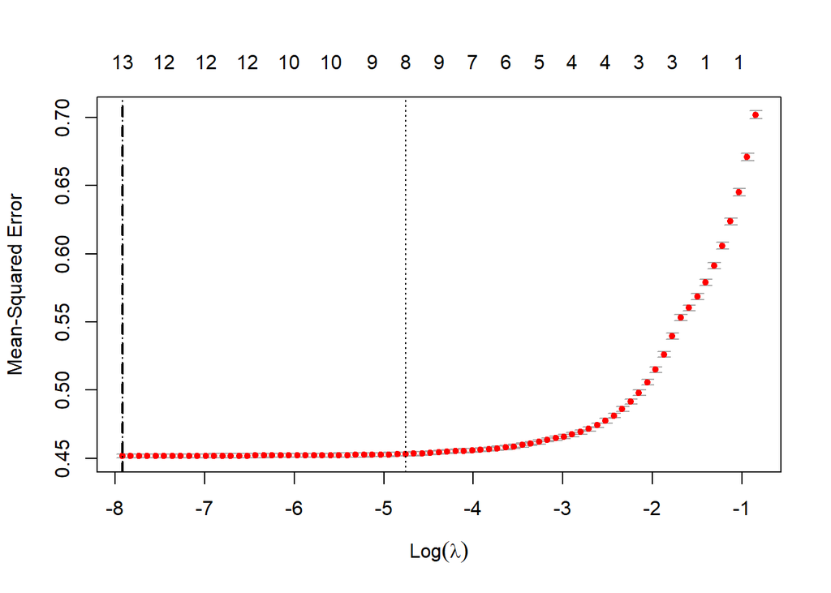

```r
# Plot the cross-validated error as a function of lambda for Lasso

plot(lasso_model)
abline(v=log(best_lambda_lasso ), col='black', lty=2, lwd=2)
```

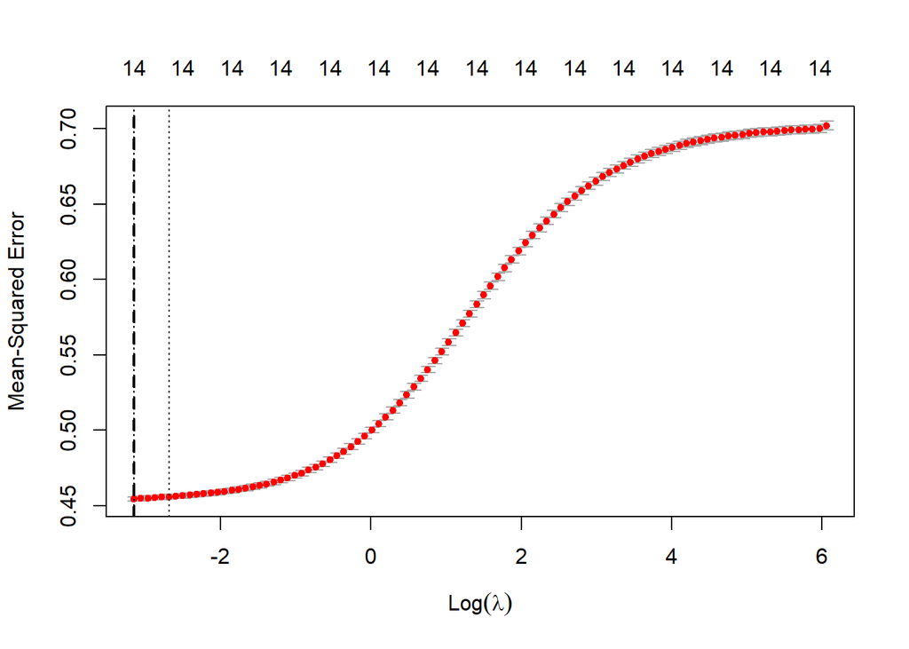

```r
# Plot the cross-validated error as a function of lambda for Ridge
plot(ridge_model)
abline(v=log(best_lambda_ridge ), col='black', lty=2, lwd=2)
```

```r
# view the coefficients of the model at the optimal lambda
coef(lasso_model,best_lambda_lasso)
```

```
## 16 x 1 sparse Matrix of class "dgCMatrix"
##                                              s1
## (Intercept)                        1.411038e+01
## state                              .
## year                              -8.918910e-04
## month                             -1.377956e-03
## house_size_filled_capped           2.752353e-05
## bed_filled_capped                 -2.165106e-02
## bath_filled_capped                 4.082271e-01
## acre_lot_filled_capped             4.967187e-02
## bed/house_size_filled_capped       3.374632e+01
## bath/house_size_filled_capped     -2.342334e+02
## bed/acre_lot_filled_capped         1.827163e-03
## bath/acre_lot_filled_capped       -8.552255e-06
## house_size/acre_lot_filled_capped  5.733012e-07
## bed_vs_bathbed_equal_bath          .
## bed_vs_bathbed_less_than_bath      2.429678e-02
## bed_vs_bathbed_more_than_bath     -1.247166e-01
```

```r
coef(ridge_model,best_lambda_ridge)
```

```
## 16 x 1 sparse Matrix of class "dgCMatrix"
##                                              s1
## (Intercept)                        1.382493e+01
## state                              .
## year                              -8.288135e-04
## month                             -1.400402e-03
## house_size_filled_capped           1.036091e-04
## bed_filled_capped                  3.698385e-02
## bath_filled_capped                 2.577137e-01
## acre_lot_filled_capped             4.489533e-02
## bed/house_size_filled_capped      -2.179530e+01
## bath/house_size_filled_capped     -3.146991e+01
## bed/acre_lot_filled_capped         9.966434e-04
## bath/acre_lot_filled_capped        8.636039e-04
## house_size/acre_lot_filled_capped  2.441562e-07
## bed_vs_bathbed_equal_bath          5.886665e-02
## bed_vs_bathbed_less_than_bath      1.508592e-01
## bed_vs_bathbed_more_than_bath     -1.009611e-01
```

```r
ridgemodel = glmnet(x_train, y_train, alpha=0, nlambda=100)
lassomodel = glmnet(x_train, y_train, alpha=1, nlambda=100)
```

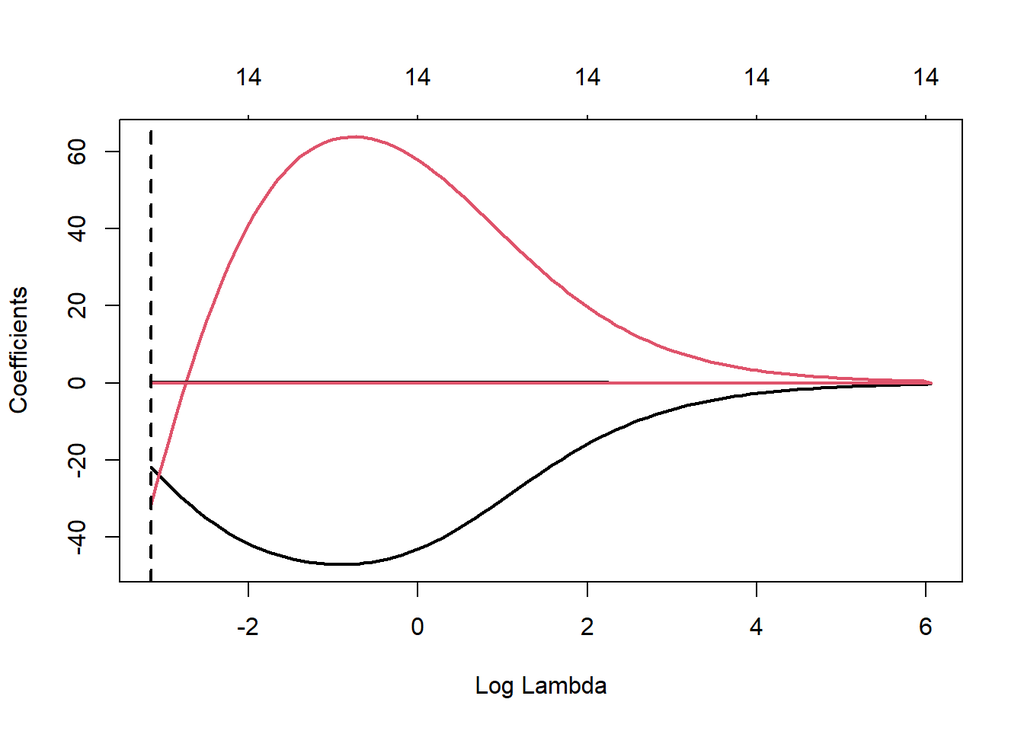

```r
plot(ridgemodel, xvar="lambda", lwd=2)
abline(v=log(best_lambda_ridge), col='black', lty=2, lwd=2)
```

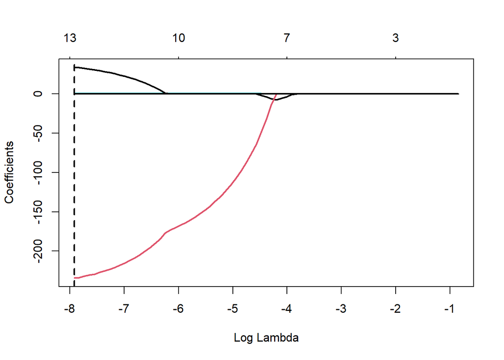

```r
plot(lassomodel, xvar="lambda", lwd=2)
abline(v=log(best_lambda_lasso), col='black', lty=2, lwd=2)
```

11 Elastic Net

```r
# Perform cross-validated Elastic Net regression
# Vary the alpha parameter between 0 (ridge) and 1 (lasso)
enmodel <- cv.glmnet(x_train, y_train, alpha = 0.5, lambda = NULL, standardize = TRUE, cv.glmnetControl = cv_control)
```

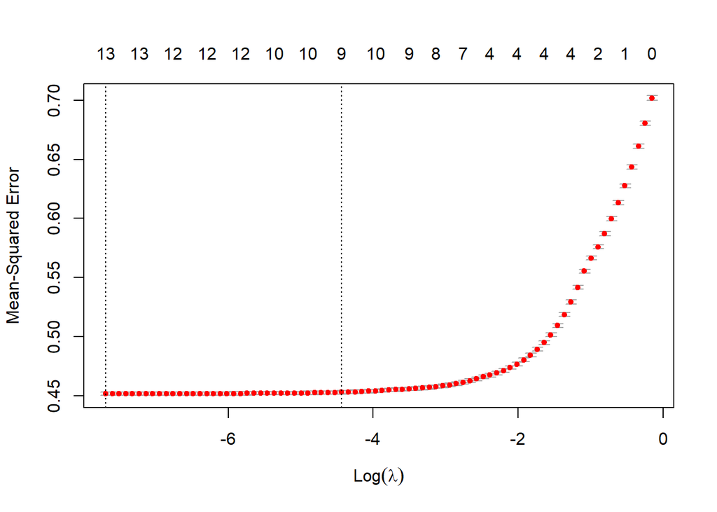

```r
# Plot the cross-validated error as a function of lambda for Elastic Net
plot(enmodel)
```

```r
summary(enmodel)
```

```
##            Length Class  Mode
## lambda     82     -none- numeric
## cvm        82     -none- numeric
## cvsd       82     -none- numeric
## cvup       82     -none- numeric
## cvlo       82     -none- numeric
## nzero      82     -none- numeric
## call        7     -none- call
## name        1     -none- character
## glmnet.fit 12     elnet  list
## lambda.min  1     -none- numeric
## lambda.1se  1     -none- numeric
## index       2     -none- numeric
```

```r
# Choose the optimal alpha and lambda values
best_alpha_en <- enmodel$alpha
best_lambda_en <- enmodel$lambda.min

cat("best alpha:", best_alpha_en)
```

```
## best alpha:
```

```r
cat("best lambda:",best_lambda_en)
```

```
## best lambda: 0.0004569877
```

16 Use the selected alpha and lambda values to train the final Elastic Net model

```r
final_elastic_net_model <- glmnet(x_train, y_train, alpha = 0.5, lambda = best_lambda_en)
summary(final_elastic_net_model)
```

```
##           Length Class     Mode
## a0         1     -none-    numeric
## beta      15     dgCMatrix S4
## df         1     -none-    numeric
## dim        2     -none-    numeric
## lambda     1     -none-    numeric
## dev.ratio  1     -none-    numeric
## nulldev    1     -none-    numeric
## npasses    1     -none-    numeric
## jerr       1     -none-    numeric
## offset     1     -none-    logical
## call       5     -none-    call
## nobs       1     -none-    numeric
```

```r
# Make predictions on the validation set
en_predictions <- predict(final_elastic_net_model, newx = x_val)
# Evaluate the performance on the validation set (e.g., using mean squared error)
en_mse <- mean((en_predictions - y_val)^2)

# Print or use the MSE value as needed
print(paste("Elastic Net MSE on validation set:", en_mse))
```

```
## [1] "Elastic Net MSE on validation set: 0.452868837062652"
```

```r
## Extract coefficients at optimal lambda
coef(final_elastic_net_model, s=enmodel$lambda.min)
```

```
## 16 x 1 sparse Matrix of class "dgCMatrix"
##                                              s1
## (Intercept)                        1.403671e+01
## state                              .
## year                              -9.019507e-04
## month                             -1.417338e-03
## house_size_filled_capped           2.737707e-05
## bed_filled_capped                 -2.346148e-02
## bath_filled_capped                 4.105043e-01
## acre_lot_filled_capped             4.967147e-02
## bed/house_size_filled_capped       3.636032e+01
## bath/house_size_filled_capped     -2.374283e+02
## bed/acre_lot_filled_capped         1.875953e-03
## bath/acre_lot_filled_capped       -1.293035e-04
## house_size/acre_lot_filled_capped  6.569079e-07
## bed_vs_bathbed_equal_bath          9.445160e-02
## bed_vs_bathbed_less_than_bath      1.183861e-01
## bed_vs_bathbed_more_than_bath     -3.090655e-02
```

17 Stepwise Regression

```r
### Apply Stepwise Regression
full = lm(log(price) ~ .,data=training_data_selected2)

minimum = lm(log(price) ~ house_size_filled_capped+ bed_filled_capped+bath_filled_capped+acre_lot_filled_capped, data=training_data_selected2)
```

```r
# Forward Stepwise Regression
forward.model = step(minimum, scope=list(lower=minimum, upper=full), direction="forward",trace=F)
summary(forward.model)
```

```
##
## Call:
## lm(formula = log(price) ~ house_size_filled_capped + bed_filled_capped +
##     bath_filled_capped + acre_lot_filled_capped + state + `bath/house_size_filled_capped` +
##     year + `bath/acre_lot_filled_capped` + `house_size/acre_lot_filled_capped` +
##     month + bed_vs_bath + `bed/house_size_filled_capped` + `bed/acre_lot_filled_capped`,
##     data = training_data_selected2)
##
## Residuals:
##     Min      1Q  Median      3Q     Max
## -3.5996 -0.3155  0.0231  0.3262  6.8934
##
## Coefficients:
##                                       Estimate Std. Error t value Pr(>|t|)
## (Intercept)                          5.662e+00  2.521e-01  22.456  < 2e-16 ***
## house_size_filled_capped             1.478e-05  3.122e-06   4.735 2.20e-06 ***
## bed_filled_capped                   -2.502e-02  2.316e-03 -10.805  < 2e-16 ***
## bath_filled_capped                   4.439e-01  3.536e-03 125.528  < 2e-16 ***
## acre_lot_filled_capped               1.760e-02  2.973e-04  59.198  < 2e-16 ***
## stateMaine                           6.813e-03  1.063e-02   0.641   0.5218
## stateMassachusetts                   6.850e-01  4.279e-03 160.096  < 2e-16 ***
## stateNew Hampshire                   2.273e-01  7.204e-03  31.556  < 2e-16 ***
## stateNew Jersey                      3.419e-01  3.715e-03  92.052  < 2e-16 ***
## stateNew York                        1.112e+00  4.130e-03 269.157  < 2e-16 ***
## statePennsylvania                    8.797e-02  7.881e-03  11.163  < 2e-16 ***
## stateRhode Island                    2.979e-01  6.851e-03  43.484  < 2e-16 ***
## stateVermont                        -1.282e-01  7.841e-03 -16.349  < 2e-16 ***
## `bath/house_size_filled_capped`     -1.903e+02  6.153e+00 -30.930  < 2e-16 ***
## year                                 3.067e-03  1.253e-04  24.478  < 2e-16 ***
## `bath/acre_lot_filled_capped`       -3.281e-03  1.326e-04 -24.745  < 2e-16 ***
## `house_size/acre_lot_filled_capped`  2.862e-06  1.584e-07  18.066  < 2e-16 ***
## month2                              -2.470e-02  5.974e-03  -4.135 3.55e-05 ***
## month3                              -1.121e-03  5.736e-03  -0.195   0.8450
## month4                               5.903e-03  5.712e-03   1.033   0.3014
## month5                               2.377e-02  5.607e-03   4.239 2.24e-05 ***
## month6                               9.551e-03  5.421e-03   1.762   0.0781 .
## month7                               2.640e-02  5.385e-03   4.901 9.52e-07 ***
## month8                               3.535e-04  5.394e-03   0.066   0.9477
## month9                               3.924e-03  5.539e-03   0.708   0.4787
## month10                             -9.025e-03  5.496e-03  -1.642   0.1005
## month11                              1.452e-02  5.666e-03   2.563   0.0104 *
## month12                             -3.477e-03  5.551e-03  -0.626   0.5311
## bed_vs_bathbed_less_than_bath        2.460e-02  5.104e-03   4.820 1.43e-06 ***
## bed_vs_bathbed_more_than_bath       -2.912e-02  3.800e-03  -7.663 1.82e-14 ***
## `bed/house_size_filled_capped`       1.716e+01  3.042e+00   5.641 1.69e-08 ***
## `bed/acre_lot_filled_capped`         3.958e-04  9.300e-05   4.256 2.08e-05 ***
## ---
## Signif. codes:  0 '***' 0.001 '**' 0.01 '*' 0.05 '.' 0.1 ' ' 1
##
## Residual standard error: 0.566 on 262857 degrees of freedom
## Multiple R-squared:  0.5438, Adjusted R-squared:  0.5437
## F-statistic: 1.011e+04 on 31 and 262857 DF,  p-value: < 2.2e-16
```

```r
# Backward Stepwise Regression
backward.model = step(full, scope=list(lower=minimum, upper=full), direction = "backward",trace=F,k=log(n))
summary(backward.model)
```

```
##
## Call:
## lm(formula = log(price) ~ state + year + month + house_size_filled_capped +
##     bed_filled_capped + bath_filled_capped + acre_lot_filled_capped +
##     `bed/house_size_filled_capped` + `bath/house_size_filled_capped` +
##     bed_vs_bath + `bed/acre_lot_filled_capped` + `bath/acre_lot_filled_capped` +
##     `house_size/acre_lot_filled_capped`, data = training_data_selected2)
##
## Residuals:
##     Min      1Q  Median      3Q     Max
## -3.5996 -0.3155  0.0231  0.3262  6.8934
##
## Coefficients:
##                                       Estimate Std. Error t value Pr(>|t|)
## (Intercept)                          5.662e+00  2.521e-01  22.456  < 2e-16 ***
## stateMaine                           6.813e-03  1.063e-02   0.641   0.5218
## stateMassachusetts                   6.850e-01  4.279e-03 160.096  < 2e-16 ***
## stateNew Hampshire                   2.273e-01  7.204e-03  31.556  < 2e-16 ***
## stateNew Jersey                      3.419e-01  3.715e-03  92.052  < 2e-16 ***
## stateNew York                        1.112e+00  4.130e-03 269.157  < 2e-16 ***
## statePennsylvania                    8.797e-02  7.881e-03  11.163  < 2e-16 ***
## stateRhode Island                    2.979e-01  6.851e-03  43.484  < 2e-16 ***
## stateVermont                        -1.282e-01  7.841e-03 -16.349  < 2e-16 ***
## year                                 3.067e-03  1.253e-04  24.478  < 2e-16 ***
## month2                              -2.470e-02  5.974e-03  -4.135 3.55e-05 ***
## month3                              -1.121e-03  5.736e-03  -0.195   0.8450
## month4                               5.903e-03  5.712e-03   1.033   0.3014
## month5                               2.377e-02  5.607e-03   4.239 2.24e-05 ***
## month6                               9.551e-03  5.421e-03   1.762   0.0781 .
## month7                               2.640e-02  5.385e-03   4.901 9.52e-07 ***
## month8                               3.535e-04  5.394e-03   0.066   0.9477
## month9                               3.924e-03  5.539e-03   0.708   0.4787
## month10                             -9.025e-03  5.496e-03  -1.642   0.1005
## month11                              1.452e-02  5.666e-03   2.563   0.0104 *
## month12                             -3.477e-03  5.551e-03  -0.626   0.5311
## house_size_filled_capped             1.478e-05  3.122e-06   4.735 2.20e-06 ***
## bed_filled_capped                   -2.502e-02  2.316e-03 -10.805  < 2e-16 ***
## bath_filled_capped                   4.439e-01  3.536e-03 125.528  < 2e-16 ***
## acre_lot_filled_capped               1.760e-02  2.973e-04  59.198  < 2e-16 ***
## `bed/house_size_filled_capped`       1.716e+01  3.042e+00   5.641 1.69e-08 ***
## `bath/house_size_filled_capped`     -1.903e+02  6.153e+00 -30.930  < 2e-16 ***
## bed_vs_bathbed_less_than_bath        2.460e-02  5.104e-03   4.820 1.43e-06 ***
## bed_vs_bathbed_more_than_bath       -2.912e-02  3.800e-03  -7.663 1.82e-14 ***
## `bed/acre_lot_filled_capped`         3.958e-04  9.300e-05   4.256 2.08e-05 ***
## `bath/acre_lot_filled_capped`       -3.281e-03  1.326e-04 -24.745  < 2e-16 ***
## `house_size/acre_lot_filled_capped`  2.862e-06  1.584e-07  18.066  < 2e-16 ***
## ---
## Signif. codes:  0 '***' 0.001 '**' 0.01 '*' 0.05 '.' 0.1 ' ' 1
##
## Residual standard error: 0.566 on 262857 degrees of freedom
## Multiple R-squared:  0.5438, Adjusted R-squared:  0.5437
## F-statistic: 1.011e+04 on 31 and 262857 DF,  p-value: < 2.2e-16
```

```r
# Forward-Backward Stepwise Regression
both.min.model = step(minimum, scope=list(lower=minimum, upper=full), direction = "both",trace=F,k=log(n))
summary(both.min.model)
```

```
##
## Call:
## lm(formula = log(price) ~ house_size_filled_capped + bed_filled_capped +
##     bath_filled_capped + acre_lot_filled_capped + state + `bath/house_size_filled_capped` +
##     year + `bath/acre_lot_filled_capped` + `house_size/acre_lot_filled_capped` +
##     bed_vs_bath + `bed/house_size_filled_capped` + `bed/acre_lot_filled_capped` +
##     month, data = training_data_selected2)
##
## Residuals:
##     Min      1Q  Median      3Q     Max
## -3.5996 -0.3155  0.0231  0.3262  6.8934
##
## Coefficients:
##                                       Estimate Std. Error t value Pr(>|t|)
## (Intercept)                          5.662e+00  2.521e-01  22.456  < 2e-16 ***
## house_size_filled_capped             1.478e-05  3.122e-06   4.735 2.20e-06 ***
## bed_filled_capped                   -2.502e-02  2.316e-03 -10.805  < 2e-16 ***
## bath_filled_capped                   4.439e-01  3.536e-03 125.528  < 2e-16 ***
## acre_lot_filled_capped               1.760e-02  2.973e-04  59.198  < 2e-16 ***
## stateMaine                           6.813e-03  1.063e-02   0.641   0.5218
## stateMassachusetts                   6.850e-01  4.279e-03 160.096  < 2e-16 ***
## stateNew Hampshire                   2.273e-01  7.204e-03  31.556  < 2e-16 ***
## stateNew Jersey                      3.419e-01  3.715e-03  92.052  < 2e-16 ***
## stateNew York                        1.112e+00  4.130e-03 269.157  < 2e-16 ***
## statePennsylvania                    8.797e-02  7.881e-03  11.163  < 2e-16 ***
## stateRhode Island                    2.979e-01  6.851e-03  43.484  < 2e-16 ***
## stateVermont                        -1.282e-01  7.841e-03 -16.349  < 2e-16 ***
## `bath/house_size_filled_capped`     -1.903e+02  6.153e+00 -30.930  < 2e-16 ***
## year                                 3.067e-03  1.253e-04  24.478  < 2e-16 ***
## `bath/acre_lot_filled_capped`       -3.281e-03  1.326e-04 -24.745  < 2e-16 ***
## `house_size/acre_lot_filled_capped`  2.862e-06  1.584e-07  18.066  < 2e-16 ***
## bed_vs_bathbed_less_than_bath        2.460e-02  5.104e-03   4.820 1.43e-06 ***
## bed_vs_bathbed_more_than_bath       -2.912e-02  3.800e-03  -7.663 1.82e-14 ***
## `bed/house_size_filled_capped`       1.716e+01  3.042e+00   5.641 1.69e-08 ***
## `bed/acre_lot_filled_capped`         3.958e-04  9.300e-05   4.256 2.08e-05 ***
## month2                              -2.470e-02  5.974e-03  -4.135 3.55e-05 ***
## month3                              -1.121e-03  5.736e-03  -0.195   0.8450
## month4                               5.903e-03  5.712e-03   1.033   0.3014
## month5                               2.377e-02  5.607e-03   4.239 2.24e-05 ***
## month6                               9.551e-03  5.421e-03   1.762   0.0781 .
## month7                               2.640e-02  5.385e-03   4.901 9.52e-07 ***
## month8                               3.535e-04  5.394e-03   0.066   0.9477
## month9                               3.924e-03  5.539e-03   0.708   0.4787
## month10                             -9.025e-03  5.496e-03  -1.642   0.1005
## month11                              1.452e-02  5.666e-03   2.563   0.0104 *
## month12                             -3.477e-03  5.551e-03  -0.626   0.5311
## ---
## Signif. codes:  0 '***' 0.001 '**' 0.01 '*' 0.05 '.' 0.1 ' ' 1
##
## Residual standard error: 0.566 on 262857 degrees of freedom
## Multiple R-squared:  0.5438, Adjusted R-squared:  0.5437
## F-statistic: 1.011e+04 on 31 and 262857 DF,  p-value: < 2.2e-16
```

```r
test_data<-arrow::read_parquet("test_data.parquet")

test_data$month <- as.character(test_data$month)
all(columns_to_keep2 %in% names(test_data))
```

```
## [1] TRUE
```

```r
test_data2<- test_data[, columns_to_keep2]
encoded_vars2 <- model.matrix(~ bed_vs_bath - 1, data = test_data2)
test_data2<- cbind(test_data2, encoded_vars2)
test_data2$bed_vs_bath <- NULL
```

```r
test_x <- test_data[,-1]
test_y <- log(test_data[,1])
test_x2 <- test_data2[,-1]
test_y2<-log(test_data2[,1])

#full model = model2
pred_full <- predict(log_model2, test_x,type="response")
cat("Full Model prediction:\n")
```

```
## Full Model prediction:
```

```r
pred_full[1:5]
```

```
##        1        2        3        4        5
## 12.32806 12.86199 13.30232 14.00269 13.65764
```

```r
# 2 -way stepwise regression with BIC=both.min.model
pred_step <- predict(both.min.model, test_x,type="response")
cat("Stepwise regression model prediction:\n")
```

```
## Stepwise regression model prediction:
```

```r
pred_step[1:5]
```

```
##        1        2        3        4        5
## 12.32806 12.86199 13.30232 14.00269 13.65764
```

```r
# ridge regression
pred_ridge <- predict(final_ridge_model, as.matrix(test_x2),s=best_lambda_ridge)
cat("Ridge regression model prediction:\n")
```

```
## Ridge regression model prediction:
```

```r
pred_ridge[1:5]
```

```
## [1] 12.92319 13.51361 12.96650 13.25313 13.35197
```

```r
#lasso regression
pred_lasso <- predict(final_lasso_model, as.matrix(test_x2),s=best_lambda_lasso)
cat("Lasso regression model prediction:\n")
```

```
## Lasso regression model prediction:
```

```r
pred_lasso[1:5]
```

```
## [1] 12.93791 13.56072 12.93314 13.26048 13.23810
```

```r
#elastic net
pred_ela <- predict(final_elastic_net_model, as.matrix(test_x2),s=best_lambda_en)
cat("Elastic net model prediction:\n")
```

```
## Elastic net model prediction:
```

```r
pred_ela[1:5]
```

```
## [1] 12.93805 13.56028 12.93285 13.26035 13.23728
```

```r
#Calculate RMSE
rmse_full<- sqrt(mean((pred_full-test_y2)^2))
rmse_step<- sqrt(mean((pred_step-test_y2)^2))
rmse_ridge<- sqrt(mean((pred_ridge-test_y2)^2))
rmse_lasso<-  sqrt(mean((pred_lasso-test_y2)^2))
rmse_elanet<- sqrt(mean((pred_ela-test_y2)^2))

rmse_full
```

```
## [1] 0.5678201
```

```r
rmse_step
```

```
## [1] 0.5678201
```

```r
rmse_ridge
```

```
## [1] 0.6757534
```

```r
rmse_lasso
```

```
## [1] 0.6734353
```

```r
rmse_elanet
```

```
## [1] 0.6734284
```

```r
#install.packages("kableExtra")
library(dplyr)
library(kableExtra)
RMSE <- c(rmse_full,rmse_step,rmse_ridge,rmse_lasso,rmse_elanet)
models <- c("Full model(Model 2)","Stepwise","Ridge model", "Lasso model", "Elastic net model")
df2 <- data.frame(models,RMSE)
df2 <- df2 %>% arrange((RMSE))
#create kable table
df2 %>%
  kbl(caption="Table II: Prediction Performance") %>%
  kable_styling(bootstrap_options = c("striped", "hover"), position="center") %>%
  kable_classic(full_width = F, html_font = "Cambria") %>% row_spec(0, bold=T, background="yellow")
```

Table II: Prediction Performance

| models | RMSE |
| --- | --- |
| Full model(Model 2) | 0.5678201 |
| Stepwise | 0.5678201 |
| Elastic net model | 0.6734284 |
| Lasso model | 0.6734353 |
| Ridge model | 0.6757534 |

```r
combined <- cbind(actual_col = test_y2, pred_col = pred_full)

# Convert the result to a data frame for better readability (optional)
combined_df <- as.data.frame(combined)
write.csv(combined_df, file = "prediction_result.csv", row.names = FALSE)
```

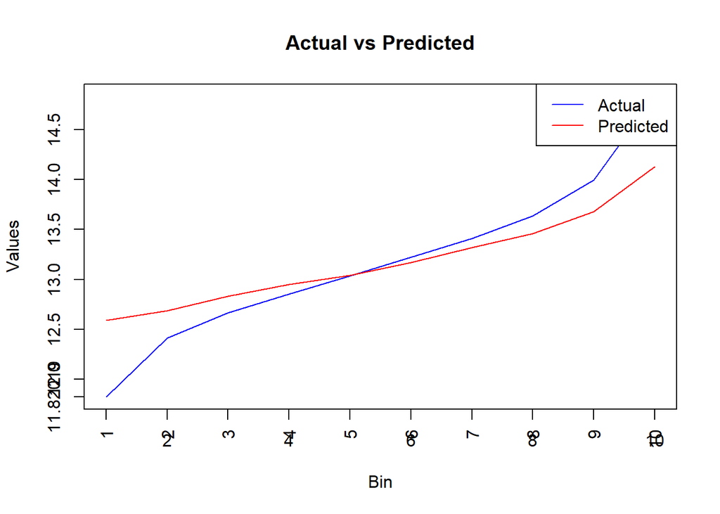

```r
actual_vs_predicted <- function(input, actual_col, pred_col) {
  df <- input
  df <- df[order(df[[actual_col]]),]
  df$bin <- cut(df[[actual_col]], breaks = quantile(df[[actual_col]], probs = seq(0, 1, by = 0.1), na.rm = TRUE), include.lowest = TRUE, labels = FALSE)

  grouped <- aggregate(cbind(df[[actual_col]], df[[pred_col]]), by = list(df$bin), FUN = mean)
  colnames(grouped) <- c('bin', actual_col, pred_col)

  plot(grouped[[actual_col]], type = 'l', col = 'blue', xlab = 'Bin', ylab = 'Values', main = 'Actual vs Predicted')
  lines(grouped[[pred_col]], col = 'red')
  legend("topright", legend = c('Actual', 'Predicted'), col = c('blue', 'red'), lty = 1)
  xlim <- c(1, length(unique(df$bin)))
  ylim <- range(c(grouped[[actual_col]], grouped[[pred_col]]))
  axis(1, at = seq(xlim[1], xlim[2], by = 1), labels = levels(df$bin), las = 2)
  axis(2, at = seq(ylim[1], ylim[2], by = 10))

  grouped['% diff'] <- (grouped[[pred_col]] / grouped[[actual_col]] - 1) * 100
  result_df <- grouped

  return(result_df)
}


# Example usage:
result <- actual_vs_predicted(combined_df, "actual_col", "pred_col")
```

```r
result
```

```
##    bin actual_col pred_col     % diff
## 1    1   11.82019 12.59030  6.5152479
## 2    2   12.41158 12.68425  2.1969321
## 3    3   12.66193 12.83060  1.3320512
## 4    4   12.85514 12.94978  0.7361675
## 5    5   13.03484 13.03892  0.0312269
## 6    6   13.22158 13.16727 -0.4107706
## 7    7   13.41261 13.31943 -0.6946797
## 8    8   13.63733 13.46001 -1.3002686
## 9    9   13.99856 13.67817 -2.2887622
## 10  10   14.83807 14.12880 -4.7800881
```

```r
summary(log_model2)
```

```
##
## Call:
## lm(formula = log(price) ~ ., data = training_data_selected2)
##
## Residuals:
##     Min      1Q  Median      3Q     Max
## -3.5996 -0.3155  0.0231  0.3262  6.8934
##
## Coefficients:
##                                       Estimate Std. Error t value Pr(>|t|)
## (Intercept)                          5.662e+00  2.521e-01  22.456  < 2e-16 ***
## stateMaine                           6.813e-03  1.063e-02   0.641   0.5218
## stateMassachusetts                   6.850e-01  4.279e-03 160.096  < 2e-16 ***
## stateNew Hampshire                   2.273e-01  7.204e-03  31.556  < 2e-16 ***
## stateNew Jersey                      3.419e-01  3.715e-03  92.052  < 2e-16 ***
## stateNew York                        1.112e+00  4.130e-03 269.157  < 2e-16 ***
## statePennsylvania                    8.797e-02  7.881e-03  11.163  < 2e-16 ***
## stateRhode Island                    2.979e-01  6.851e-03  43.484  < 2e-16 ***
## stateVermont                        -1.282e-01  7.841e-03 -16.349  < 2e-16 ***
## year                                 3.067e-03  1.253e-04  24.478  < 2e-16 ***
## month2                              -2.470e-02  5.974e-03  -4.135 3.55e-05 ***
## month3                              -1.121e-03  5.736e-03  -0.195   0.8450
## month4                               5.903e-03  5.712e-03   1.033   0.3014
## month5                               2.377e-02  5.607e-03   4.239 2.24e-05 ***
## month6                               9.551e-03  5.421e-03   1.762   0.0781 .
## month7                               2.640e-02  5.385e-03   4.901 9.52e-07 ***
## month8                               3.535e-04  5.394e-03   0.066   0.9477
## month9                               3.924e-03  5.539e-03   0.708   0.4787
## month10                             -9.025e-03  5.496e-03  -1.642   0.1005
## month11                              1.452e-02  5.666e-03   2.563   0.0104 *
## month12                             -3.477e-03  5.551e-03  -0.626   0.5311
## house_size_filled_capped             1.478e-05  3.122e-06   4.735 2.20e-06 ***
## bed_filled_capped                   -2.502e-02  2.316e-03 -10.805  < 2e-16 ***
## bath_filled_capped                   4.439e-01  3.536e-03 125.528  < 2e-16 ***
## acre_lot_filled_capped               1.760e-02  2.973e-04  59.198  < 2e-16 ***
## `bed/house_size_filled_capped`       1.716e+01  3.042e+00   5.641 1.69e-08 ***
## `bath/house_size_filled_capped`     -1.903e+02  6.153e+00 -30.930  < 2e-16 ***
## bed_vs_bathbed_less_than_bath        2.460e-02  5.104e-03   4.820 1.43e-06 ***
## bed_vs_bathbed_more_than_bath       -2.912e-02  3.800e-03  -7.663 1.82e-14 ***
## `bed/acre_lot_filled_capped`         3.958e-04  9.300e-05   4.256 2.08e-05 ***
## `bath/acre_lot_filled_capped`       -3.281e-03  1.326e-04 -24.745  < 2e-16 ***
## `house_size/acre_lot_filled_capped`  2.862e-06  1.584e-07  18.066  < 2e-16 ***
## ---
## Signif. codes:  0 '***' 0.001 '**' 0.01 '*' 0.05 '.' 0.1 ' ' 1
##
## Residual standard error: 0.566 on 262857 degrees of freedom
## Multiple R-squared:  0.5438, Adjusted R-squared:  0.5437
## F-statistic: 1.011e+04 on 31 and 262857 DF,  p-value: < 2.2e-16
```

```r
summary(both.min.model)
```

```
##
## Call:
## lm(formula = log(price) ~ house_size_filled_capped + bed_filled_capped +
##     bath_filled_capped + acre_lot_filled_capped + state + `bath/house_size_filled_capped` +
##     year + `bath/acre_lot_filled_capped` + `house_size/acre_lot_filled_capped` +
##     bed_vs_bath + `bed/house_size_filled_capped` + `bed/acre_lot_filled_capped` +
##     month, data = training_data_selected2)
##
## Residuals:
##     Min      1Q  Median      3Q     Max
## -3.5996 -0.3155  0.0231  0.3262  6.8934
##
## Coefficients:
##                                       Estimate Std. Error t value Pr(>|t|)
## (Intercept)                          5.662e+00  2.521e-01  22.456  < 2e-16 ***
## house_size_filled_capped             1.478e-05  3.122e-06   4.735 2.20e-06 ***
## bed_filled_capped                   -2.502e-02  2.316e-03 -10.805  < 2e-16 ***
## bath_filled_capped                   4.439e-01  3.536e-03 125.528  < 2e-16 ***
## acre_lot_filled_capped               1.760e-02  2.973e-04  59.198  < 2e-16 ***
## stateMaine                           6.813e-03  1.063e-02   0.641   0.5218
## stateMassachusetts                   6.850e-01  4.279e-03 160.096  < 2e-16 ***
## stateNew Hampshire                   2.273e-01  7.204e-03  31.556  < 2e-16 ***
## stateNew Jersey                      3.419e-01  3.715e-03  92.052  < 2e-16 ***
## stateNew York                        1.112e+00  4.130e-03 269.157  < 2e-16 ***
## statePennsylvania                    8.797e-02  7.881e-03  11.163  < 2e-16 ***
## stateRhode Island                    2.979e-01  6.851e-03  43.484  < 2e-16 ***
## stateVermont                        -1.282e-01  7.841e-03 -16.349  < 2e-16 ***
## `bath/house_size_filled_capped`     -1.903e+02  6.153e+00 -30.930  < 2e-16 ***
## year                                 3.067e-03  1.253e-04  24.478  < 2e-16 ***
## `bath/acre_lot_filled_capped`       -3.281e-03  1.326e-04 -24.745  < 2e-16 ***
## `house_size/acre_lot_filled_capped`  2.862e-06  1.584e-07  18.066  < 2e-16 ***
## bed_vs_bathbed_less_than_bath        2.460e-02  5.104e-03   4.820 1.43e-06 ***
## bed_vs_bathbed_more_than_bath       -2.912e-02  3.800e-03  -7.663 1.82e-14 ***
## `bed/house_size_filled_capped`       1.716e+01  3.042e+00   5.641 1.69e-08 ***
## `bed/acre_lot_filled_capped`         3.958e-04  9.300e-05   4.256 2.08e-05 ***
## month2                              -2.470e-02  5.974e-03  -4.135 3.55e-05 ***
## month3                              -1.121e-03  5.736e-03  -0.195   0.8450
## month4                               5.903e-03  5.712e-03   1.033   0.3014
## month5                               2.377e-02  5.607e-03   4.239 2.24e-05 ***
## month6                               9.551e-03  5.421e-03   1.762   0.0781 .
## month7                               2.640e-02  5.385e-03   4.901 9.52e-07 ***
## month8                               3.535e-04  5.394e-03   0.066   0.9477
## month9                               3.924e-03  5.539e-03   0.708   0.4787
## month10                             -9.025e-03  5.496e-03  -1.642   0.1005
## month11                              1.452e-02  5.666e-03   2.563   0.0104 *
## month12                             -3.477e-03  5.551e-03  -0.626   0.5311
## ---
## Signif. codes:  0 '***' 0.001 '**' 0.01 '*' 0.05 '.' 0.1 ' ' 1
##
## Residual standard error: 0.566 on 262857 degrees of freedom
## Multiple R-squared:  0.5438, Adjusted R-squared:  0.5437
## F-statistic: 1.011e+04 on 31 and 262857 DF,  p-value: < 2.2e-16
```

```r
validation_data$month <- as.character(validation_data$month)
valid_full_log<-predict(log_model2, validation_data, type="response")
valid_full<-exp(valid_full_log)



rmse_valid_log<- sqrt(mean((valid_full_log - log(validation_data$price))^2))
rmse_valid_log
```

```
## [1] 0.5653679
```

```r
rmse_valid<-sqrt(mean((valid_full- validation_data$price)^2))
rmse_valid
```

```
## [1] 1248450
```

```r
test_full_log<-predict(log_model2, test_data,type="response")

length(test_full_log)
```

```
## [1] 87630
```

```r
test_full<-exp(test_full_log)
length(test_full)
```

```
## [1] 87630
```

```r
rmse_test_log<- sqrt(mean((test_full_log - log(test_data$price))^2))
rmse_test_log
```

```
## [1] 0.5678201
```

```r
rmse_test<-sqrt(mean((test_full- test_data$price)^2))
rmse_test
```

```
## [1] 3173411
```

```r
training_data$month <- as.character(training_data$month)
train_full_log<-predict(log_model2, training_data, type="response")
train_full<-exp(train_full_log)



rmse_train_log<- sqrt(mean((train_full_log - log(training_data$price))^2))
rmse_train_log
```

```
## [1] 0.5659651
```

```r
rmse_train<-sqrt(mean((train_full- training_data$price)^2))
rmse_train
```

```
## [1] 2695397
```

```r
min(test_data$year)
```

```
## [1] 1985
```

```r
new<-test_data[1,]

new_price<-predict(log_model2, new, type="response")
exp(new_price)
```

```
##        1
## 225948.6
```

```r
new1<-new
new1["year"]<-2023

new1_price<-predict(log_model2, new1, type="response")
exp(new1_price)
```

```
##      1
## 229440
```